# Patchwork

Brenda Georgina Tafoya Olvera

13/5/2020

El objetivo del patchwork es hacer que sea simple y eficiente combinar ggplots separados en el mismo gráfico.

Esto lo hace a través de:

- Montaje de los plots
- Control del diseño
- Agregar anotaciones

#### **Instalación**

La instalación se puede llevar a cabo desde el CRAN o directamente desde la página de github de Thomas Lin Pederson (el creador de patchwork).

```r
#Desde el CRAN
install.packages("patchwork")

#Desde github
install.packages("devtools")
library(devtools)
install_github("thomasp85/patchwork")
```

#### **Montaje de los plots**

Cargamos las librerías que utilizaremos.

```r
library(ggplot2)
library(patchwork)
library(dplyr)
```

Primero crearemos algunos objetos ggplot básicos para explicar las diferentes opciones que ofrece patchwork, en este caso usaremos el dataset de mtcars

```r
p1 <- mtcars %>%
  ggplot() +
  geom_point(aes(mpg, disp)) +
  ggtitle('Plot 1')

p2 <- mtcars %>%
  ggplot() +
  geom_boxplot(aes(gear, disp, group = gear)) +
  ggtitle('Plot 2')

p3 <- mtcars %>%
  ggplot() +
  geom_point(aes(hp, wt, colour = mpg)) +
  ggtitle('Plot 3')

p4 <- mtcars %>%
  ggplot() +
  geom_bar(aes(gear)) +
  facet_wrap(~cyl) +
  ggtitle('Plot 4')
```

El uso más simple es la extensión del operador **+** usado en ggplot2, para permitir la unión de dos o más gráficos.

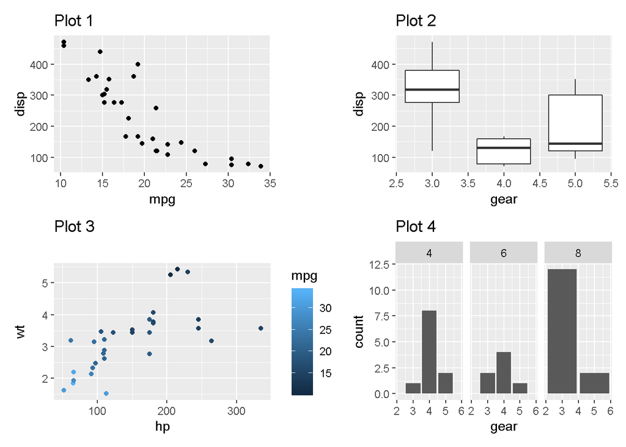

```r
p1 + p2 + p3 + p4
```

Al agregar gráficas, el último diagrama agregado será el activo y recibirá cualquier adición de nuevos objetos ggplot2 como geoms, etiquetas, etc.

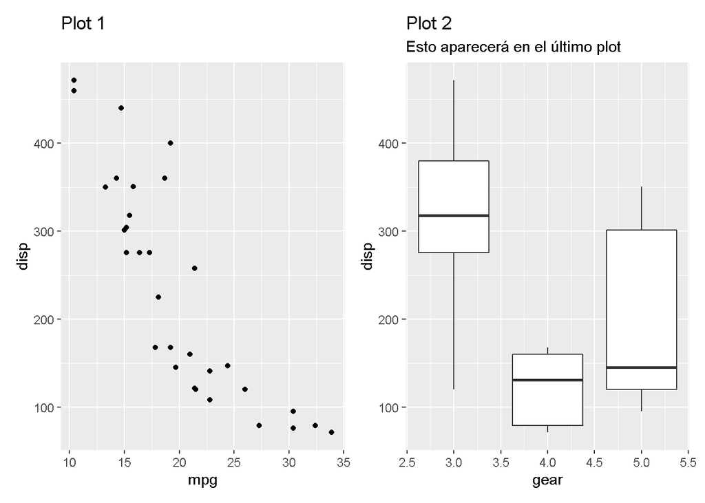

```r
p1 + p2 + labs(subtitle = 'Esto aparecerá en el último plot')
```

A menudo, queremos colocar gráficas una encima de la otra, o una al lado de la otra. Para esto patchwork proporciona dos operadores que lo hacen directamente.

- El **|** colocará las gráficas una al lado de la otra, mientras que **/** las apilará

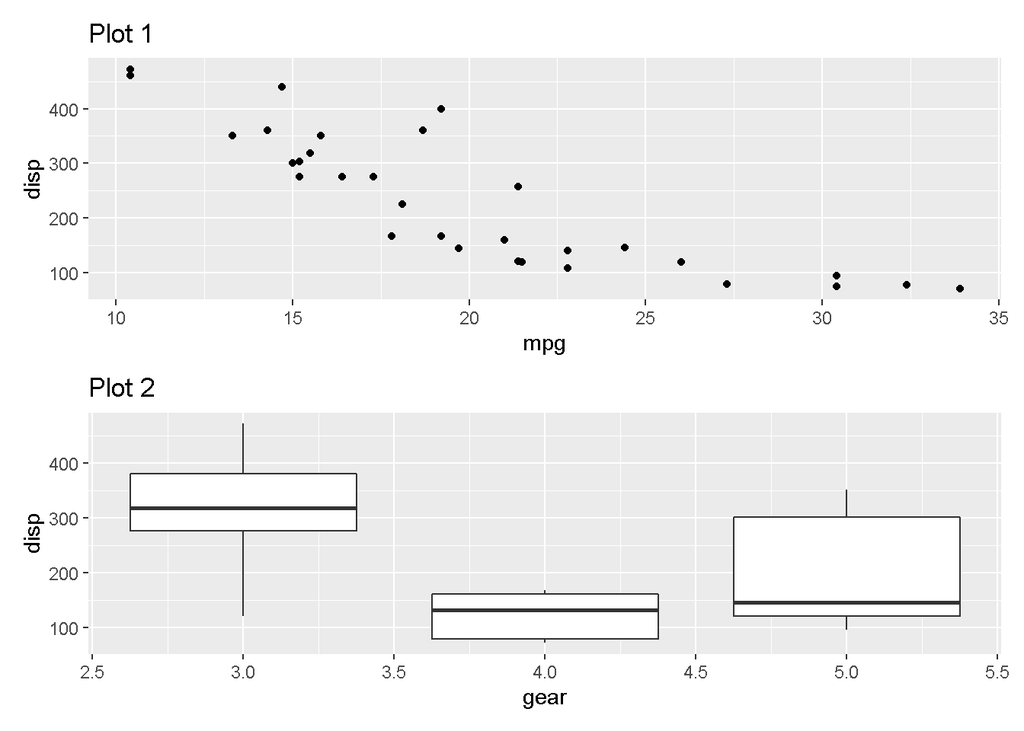

```r
#Gráficas apiladas
p1 / p2
```

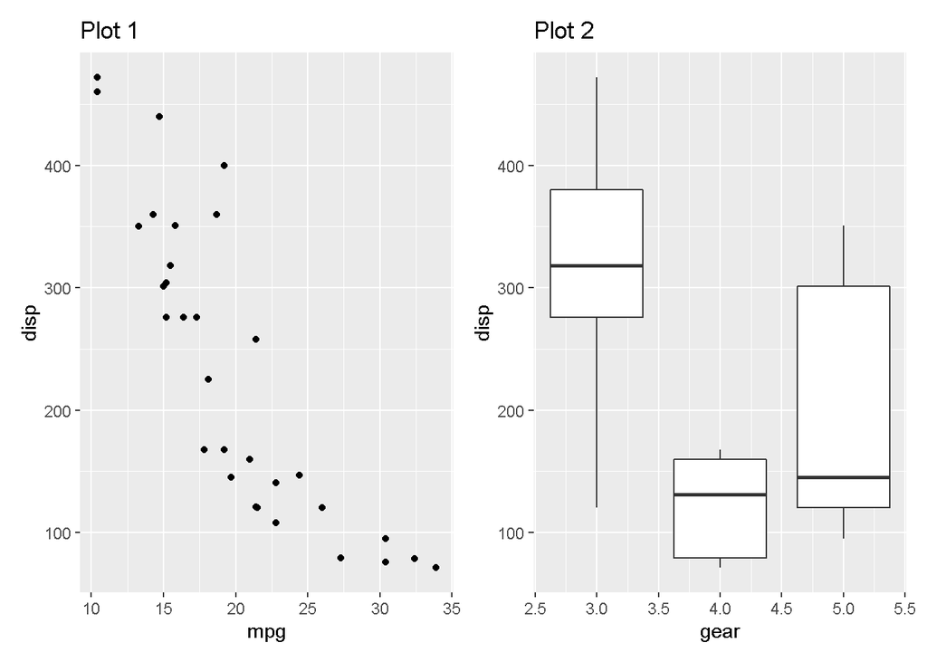

```r
#Gráficas lado a lado

p1 | p2
```

Como los patchworks se pueden anidar, estos dos operadores suelen ser suficientes para crear diseños bastante complejos

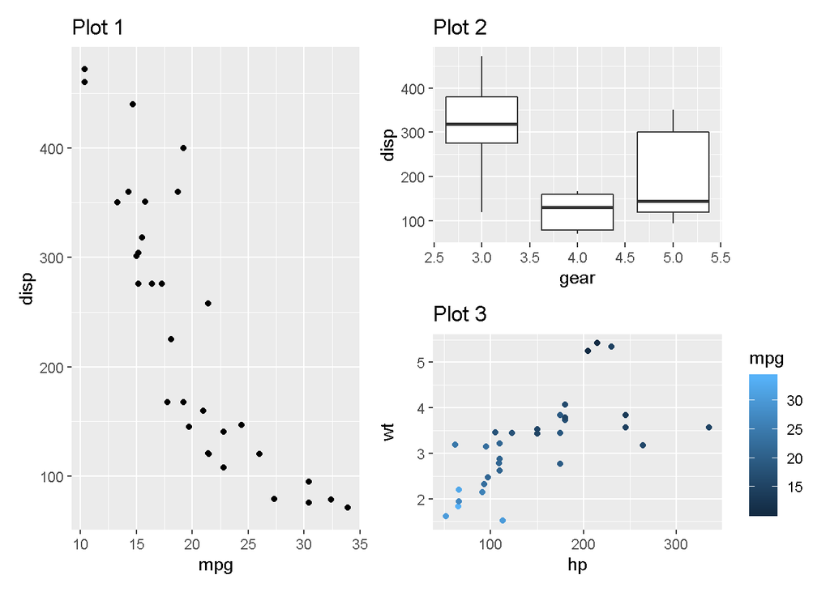

```r
p1 | (p2 / p3)
```

A veces necesitas tener otro contenido que no sea ggplot2 en tu patchwork. También se pueden agregar grid grobs a las gráficas

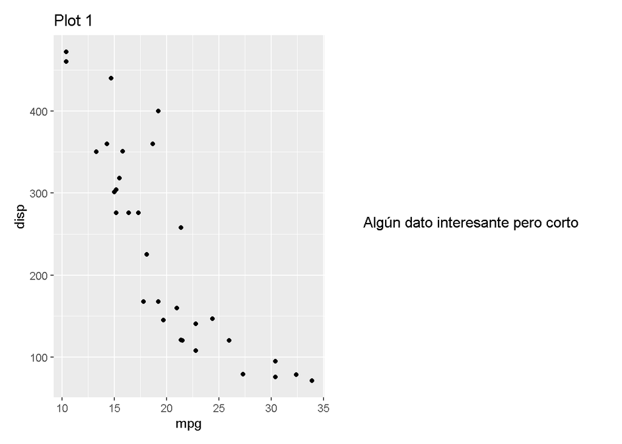

```r
p1 + grid::textGrob('Algún dato interesante pero corto ')
```

También podemos agregar tablas con el contenido de nuestra gráfica apoyándonos del paquete `gridExtra`, esto resulta útil cuando queremos mostrar datos concretos.

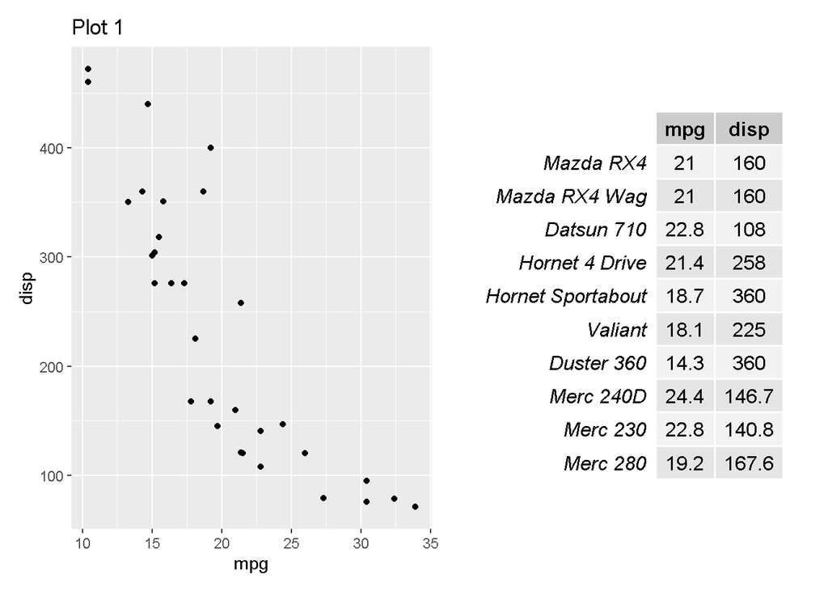

```r
p1 + gridExtra::tableGrob(mtcars[1:10, c('mpg', 'disp')])
```

#### **Control del diseño**

Si bien se pueden lograr composiciones bastante complejas usando +, | y /, puede ser necesario tomar aún más control sobre el diseño. Esto se puede controlar con la adición de `plot_layout()`.

A veces, queremos agregar un área vacía entre gráficas para facilitar la visualización de las mismas. Esto se puede hacer agregando un `plot_spacer()`. Ocupará una celda de cuadrícula de la misma manera que una gráfica sin elementos externos (títulos, marcas, tiras, etc.):

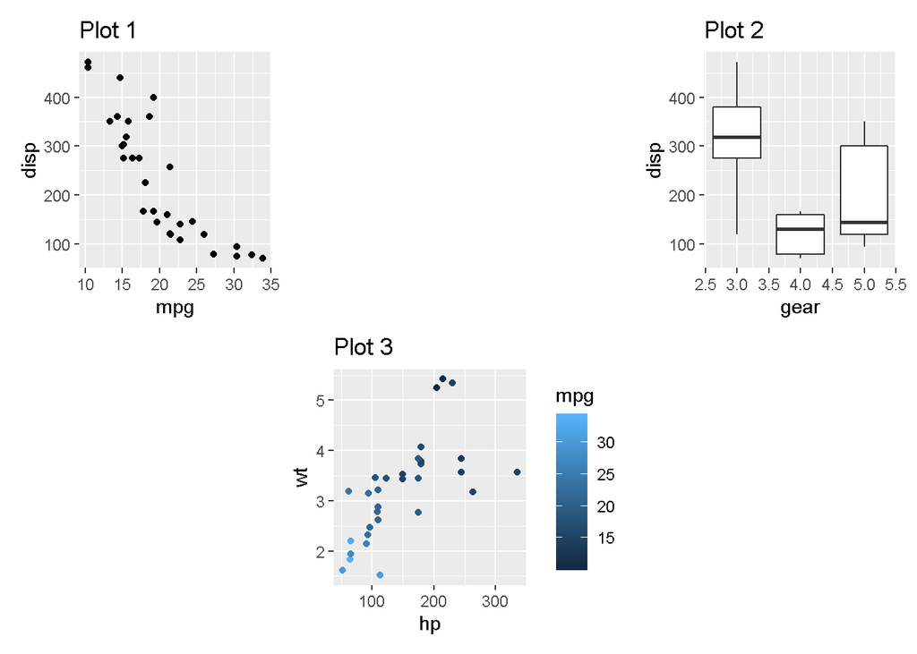

```r
p1 + plot_spacer() + p2 + plot_spacer() + p3 + plot_spacer()
```

Es importante comprender que el área agregada solo corresponde al tamaño de una gráfica. Esto significa que los espaciadores en niveles de anidamiento separados pueden tener diferentes dimensiones.

Si no se especifica lo contrario, patchwork intentará hacer una cuadrícula lo “más cuadrada posible”. La disposicón de las gráficas puede ser modificada con `plot_layout()`, veamos algunos ejemplos de esto:

En este primer ejemplo hacemos uso de `plot_layout()` para cambiar el orden en que se acomodan las gráficas (por default se colocan por fila), especificando el número de filas que queremos y el orden.

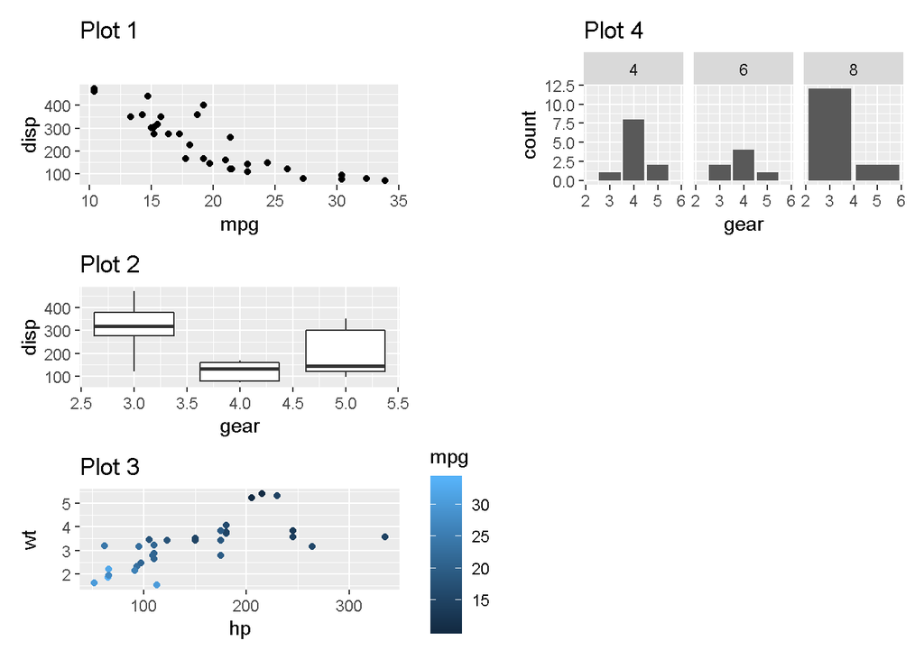

```r
p1 + p2 + p3 + p4 + plot_layout(nrow = 3, byrow = FALSE)
```

Ahora podemos ver cómo también se puede modificar la anchura de cada gráfica directamente (también podemos hacerlo de manera análoga para la altura)

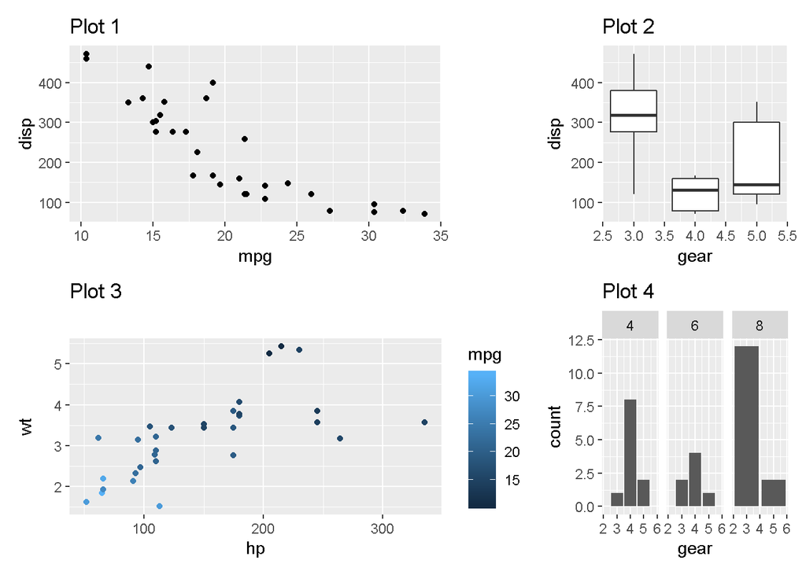

```r
p1 + p2 + p3 + p4 +
  plot_layout(widths = c(2, 1))
```

Las gráficas a menudo tienen pautas para ayudar a los espectadores a deducir el mapeo estético. Cuando agregamos gráficas, el comportamiento predeterminado es “dejarlos ser”, pero esto no siempre resulta óptimo.

La función `plot_layout ()` proporciona un argumento de pautas que controla cómo se deben tratar las pautas Para mostrar cómo funciona, veamos qué sucede si lo configuramos en “collect”

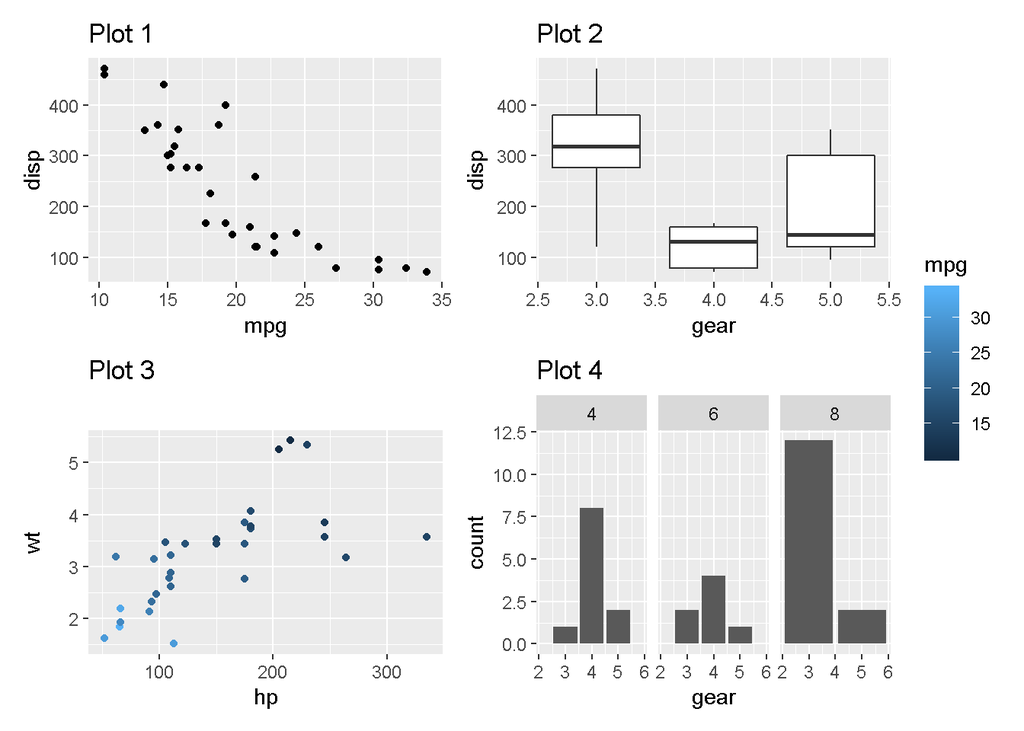

```r
p1 + p2 + p3 + p4 +
  plot_layout(guides = 'collect')
```

Podemos ver que la pauta ha sido removida y agregada nuevamente pero ahora está al lado derecho de todos los plots. Para hacer que todas nustras gráficas mantengan sus pautas usamos “keep” de igual forma.

Si varias gráficas tienen la misma pauta podemos precindir de alguna de ellas (pues idealmente no queremos tener la misma pauta repetidas veces). Al recopilar pautas, las comparará entre sí y eliminará los duplicados

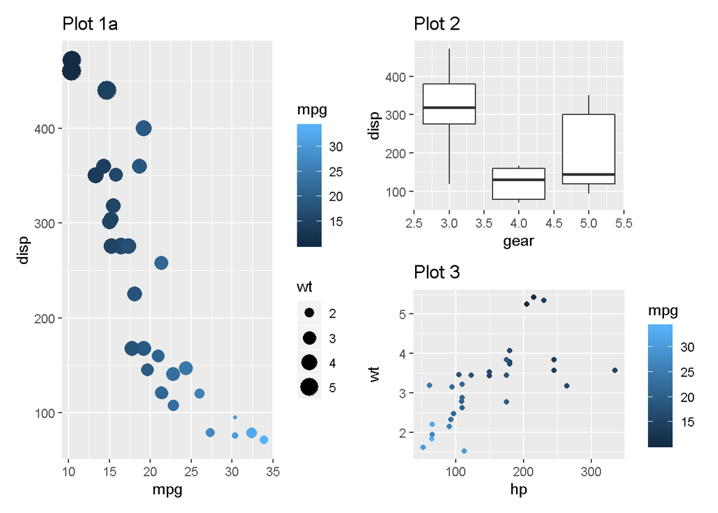

```r
#Sin guides
p1a <- ggplot(mtcars) +
  geom_point(aes(mpg, disp, colour = mpg, size = wt)) +
  ggtitle('Plot 1a')

p1a | (p2 / p3)
```

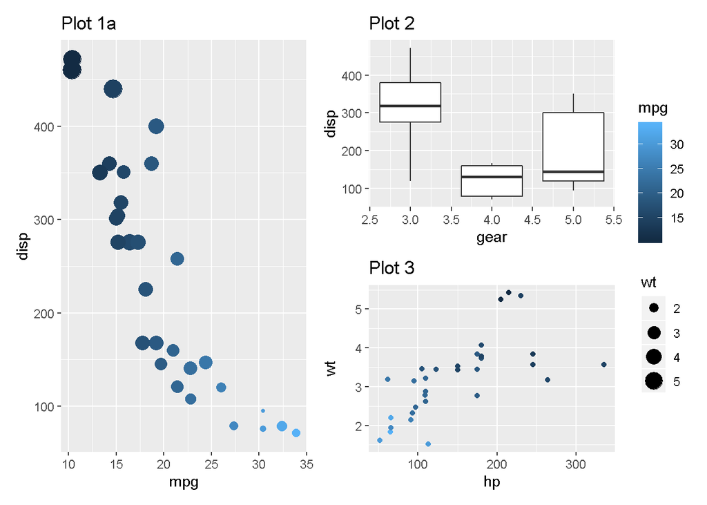

```r
#Con guides
(p1a | (p2 / p3)) + plot_layout(guides = 'collect')
```

#### **Agregar anotaciones**

A veces prensentar un conjunto de gráficas no comunica con suficiente fuerza el resultado o idea que se plantea, para esto nos apoyamos de anotaciones y leyendas. En estos casos hacemos uso de `plot_annotation()`.

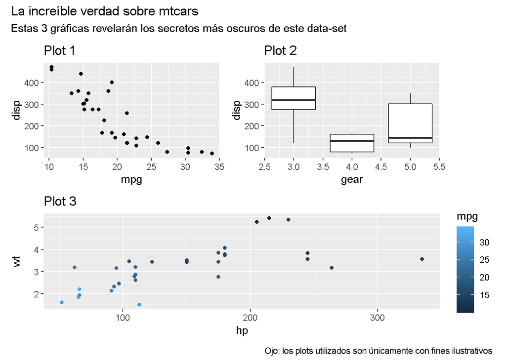

```r
patchwork <- (p1 + p2) / p3
patchwork + plot_annotation(
  title = 'La increíble verdad sobre mtcars',
  subtitle = 'Estas 3 gráficas revelarán los secretos más oscuros de este data-set',
  caption = 'Ojo: los plots utilizados son únicamente con fines ilustrativos '
)
```

*Obs:* hasta el día de hoy, estas anotaciones solo tienen efecto sobre el top-level patchwork, es decir, cualquier anotación que hagamos en un patchwork anidado se perderá :(

Otro tipo de anotación que resulta útil especialmente en literatura científica son los tags. Patchwork también puede encargarse de esto de una marea sencila agregando `tag_levels` dentro de `plot_annotation()`.

- ‘1’ es para números arábigos
- ‘A’ es para letras mayúsculas
- ‘a’ es para letras minúsculas.
- ‘I’ es para números romanos “mayúscula”
- ‘i’ es para números romanos “minúscula”

Los tags también pueden ser agregados a patchworks anidados, y personalizados en diversos aspectos.

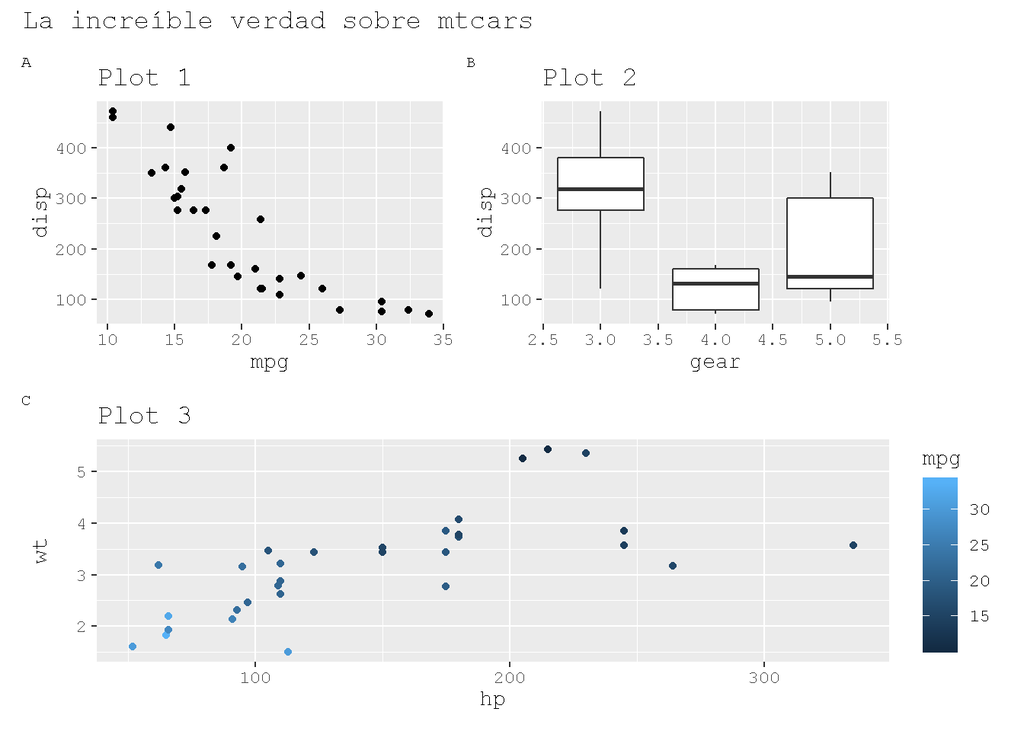

```r
patchwork +
  plot_annotation(tag_levels = 'A',
                  title = 'La increíble verdad sobre mtcars') &
  theme(plot.tag = element_text(size = 8),
        text = element_text('mono'))
```